# Homework 3

- INFO 4871 / 5871
- Spring 2019
- Ben Niu

# NOTE: LKPy 0.6.0

To do this homework, you will need to upgrade to LKPy version 0.6.0. I generally try to avoid requiring software changes in the middle of the quarter, but in this case, the benefits are (I believe) worth the hassle. Using `conda` to update should be sufficient. If you have trouble with the update not being detected (as I did on my Mac), you may need to use the `pip`+github method described at https://github.com/lenskit/lkpy.

## Objective (all students)

The object of this assignment is to gain familiarity with algorithm evaluation in LKPy. You will do this by implementing a simple hybrid recommender system and evaluating it relative to its components. I have provided the following:

- An outline of the WeightedHybrid class.
- A useful utility function my_clone in hwk3_util.py
- A simple test case for the WeightedHybrid class
- The definition of two knn algorithms UserUserFallback and ItemItemFallback in Fallbacks.py. These are also hybrids in which Bias algorithm is used to predict if not enough neighbors are found.

You will first implement the WeightedHybrid. It computes a numerical prediction from its component algorithms and then combines these in a weighted average.

```python
import pandas as pd
import matplotlib.pyplot as plt
import numpy as np
%matplotlib inline
```

```python
from lenskit import batch, topn, util
from lenskit import crossfold as xf
from lenskit.algorithms import Predictor, Recommender
from lenskit.algorithms.basic import UnratedItemCandidateSelector
from lenskit.metrics.predict import rmse
```

```python
%load_ext autoreload
%aimport Weighted_Hybrid
%aimport hwk3_util
%autoreload 2

from Weighted_Hybrid import WeightedHybrid
from hwk3_util import my_clone
from Fallbacks import UserUserFallback, ItemItemFallback
```

## 1. Implement Weighted Hybrid

```python
import unittest
from test_weighted import test_WeightedHybrid

%aimport test_weighted
```

```python
suite = unittest.TestLoader().loadTestsFromTestCase(test_weighted.test_WeightedHybrid)
runner = unittest.TextTestRunner(verbosity=2)
runner.run(suite)
```

```
test_more_components (test_weighted.test_WeightedHybrid) ... ok
test_normalize_weights (test_weighted.test_WeightedHybrid) ... ok
test_predict (test_weighted.test_WeightedHybrid) ... ok

----------------------------------------------------------------------
Ran 3 tests in 6.212s

OK
```

```
<unittest.runner.TextTestResult run=3 errors=0 failures=0>
```

## Evaluation with RMSE

### Load ratings data

```python
ratings = pd.read_csv('ratings.csv', skiprows = 1,
                      names=['user', 'item', 'rating', 'timestamp'])
ratings.head()
```

|  | user | item | rating | timestamp |
| --- | --- | --- | --- | --- |
| 0 | 12882 | 1 | 4.0 | 1147195252 |
| 1 | 12882 | 32 | 3.5 | 1147195307 |
| 2 | 12882 | 47 | 5.0 | 1147195343 |
| 3 | 12882 | 50 | 5.0 | 1147185499 |
| 4 | 12882 | 110 | 4.5 | 1147195239 |

### Create algorithms

Neighbors = 20, Min neighbors = 5

```python
algo_uu = UserUserFallback(20,5)
algo_ii = ItemItemFallback(20,5)
```

### Weighted hybrid

UserUser 0.8 ItemItem 0.2

```python
algo = WeightedHybrid([algo_uu, algo_ii], [0.8,0.2])
```

### A helper function for doing the evaluation

Makes repeated calls to `batch.predict` easier to perform.

(Adapted from LKPy "Getting started" documentation.)

```python
def eval_preds(aname, fold, algo, train, test):
    fittable = my_clone(algo)
    fittable.fit(train)

    preds = batch.predict(fittable, test)
    preds['Algorithm'] = aname
    preds['Fold'] = fold
    return preds
```

### Perform 5-fold cross-validation

Note that all the happens here is that predictions are generated. Evaluation is later.

```python
np.random.seed(20190303)

all_preds = []
fold = 1
# HOMEWORK 3 TODO
# Implement 5-fold cross-validation with user-based splitting
# Call eval_preds for each algorithm, each fold
# Results should be appended to all_preds
#test_data = []
for train, test in xf.partition_users(ratings[['user', 'item', 'rating']], 5, xf.SampleFrac(0.2)):
    #test_data.append(test)
    all_preds.append(eval_preds('ItemItem',fold,algo_uu, train, test))
    all_preds.append(eval_preds('UserUser',fold,algo_ii, train, test))
    all_preds.append(eval_preds('Hybird',fold,algo,train,test))
    print("Completed fold {}".format(fold))
    fold += 1
```

```
Completed fold 1
Completed fold 2
Completed fold 3
Completed fold 4
Completed fold 5
```

### Combine all results into one data frame

```python
all_preds = pd.concat(all_preds, ignore_index=True)
all_preds.head()
```

|  | user | item | rating | prediction | Algorithm | Fold |
| --- | --- | --- | --- | --- | --- | --- |
| 0 | 975 | 112852 | 4.0 | 3.930192 | ItemItem | 1 |
| 1 | 975 | 4011 | 4.0 | 4.083562 | ItemItem | 1 |
| 2 | 975 | 1732 | 4.5 | 4.312282 | ItemItem | 1 |
| 3 | 975 | 5952 | 3.5 | 4.038854 | ItemItem | 1 |
| 4 | 975 | 91658 | 3.5 | 3.986704 | ItemItem | 1 |

### Compute results

- Create an RMSE for each fold of each algorithm
- Compute the mean and standard deviation of over the folds for each algorithm

No loops. 2-3 or three lines of code. `groupby`, `apply`, and `agg` are your friends.

```python
Algo_rmse = all_preds.groupby(['Algorithm','Fold']).apply(lambda all_preds: rmse(all_preds.prediction, all_preds.rating))
Algo_rmse
```

```
Algorithm  Fold
Hybird     1       0.779125
           2       0.762325
           3       0.756490
           4       0.818690
           5       0.745567
ItemItem   1       0.793968
           2       0.777079
           3       0.770060
           4       0.831445
           5       0.760025
UserUser   1       0.757571
           2       0.743245
           3       0.738638
           4       0.803013
           5       0.728331
dtype: float64
```

```python
mean_std = Algo_rmse.groupby('Algorithm').agg([np.mean, np.std])
mean_std
```

| Algorithm | mean | std |
| --- | --- | --- |
| Hybird | 0.772439 | 0.028559 |
| ItemItem | 0.786515 | 0.027999 |
| UserUser | 0.754159 | 0.029264 |

```python
all_preds.groupby('Algorithm').apply(lambda all_preds: rmse(all_preds.prediction, all_preds.rating)).std()
```

```
0.016160150734115183
```

### Plot the experimental results

Bar plot with error bars. Don't forget to label the y axis.

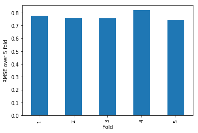

```python
user_rmse.plot.bar()
plt.ylabel('RMSE over 5 fold')
```

[figure not shown]

```python
Algo_rmse.plot.bar()
plt.ylabel('Mean RMSE over 5 fold')
```

[output not shown]

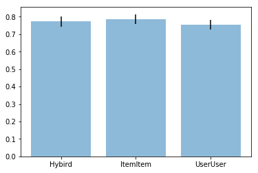

```python
#Algo_rmse.groupby('Algorithm').agg([np.mean, np.std]).plot.bar()
#plt.bar(mean_std['mean'],1,yerr = mean_std['std'] )
objects = list(mean_std.index)
y_pos = np.arange(len(objects))
performance = list(mean_std['mean'])
yerr = list(mean_std['std'])

plt.bar(y_pos,performance, align='center', yerr = yerr, alpha=0.5)
plt.xticks(y_pos, objects)
```

## Evaluation with recall / precision

### Helper function

Repeated calls to `batch.recommend`. Generate 10 recommendations.

```python
def eval_recs(aname, fold, algo, train, test):
    fittable = my_clone(algo)
    fittable = Recommender.adapt(fittable)
    fittable.fit(train)

    users = test.user.unique()
    recs = batch.recommend(fittable, users, 10)
    # add the algorithm
    recs['Algorithm'] = aname
    recs['Fold'] = fold
    return recs
```

### Perform 5-fold cross-validation

```python
np.random.seed(20190302)

all_recs = []
test_data = []
fold = 0

    # HOMEWORK 3 TODO
    # Implement 5-fold cross-validation with user-based splitting
    # Call eval_recs for each algorithm, each fold
    # Results should be appended to all_recs
    # Test data should be appended to test_data

for train, test in xf.partition_users(ratings[['user', 'item', 'rating']], 5, xf.SampleFrac(0.2)):
    test_data.append(test)
    all_recs.append(eval_recs('ItemItem',fold,algo_uu, train, test))
    all_recs.append(eval_recs('UserUser',fold,algo_ii, train, test))
    all_recs.append(eval_recs('Hybird',fold,algo,train,test))
    print("Completed fold {}".format(fold))
    fold += 1
```

```
Completed fold 0
Completed fold 1
Completed fold 2
Completed fold 3
Completed fold 4
```

### Combine results into one data frame

```python
all_recs = pd.concat(all_recs, ignore_index=True)
all_recs.head()
```

|  | item | score | user | rank | Algorithm | Fold |
| --- | --- | --- | --- | --- | --- | --- |
| 0 | 296 | 4.708202 | 359 | 1 | ItemItem | 0 |
| 1 | 7361 | 4.632040 | 359 | 2 | ItemItem | 0 |
| 2 | 589 | 4.626236 | 359 | 3 | ItemItem | 0 |
| 3 | 4973 | 4.620123 | 359 | 4 | ItemItem | 0 |
| 4 | 1193 | 4.590232 | 359 | 5 | ItemItem | 0 |

### Combine test data into a data frame

Needed by the list-oriented evaluation metrics

```python
test_data = pd.concat(test_data, ignore_index=True)
test_data.head()
```

|  | user | item | rating |
| --- | --- | --- | --- |
| 0 | 359 | 4144 | 3.0 |
| 1 | 359 | 3061 | 4.5 |
| 2 | 359 | 800 | 4.0 |
| 3 | 359 | 8985 | 4.0 |
| 4 | 359 | 48043 | 4.0 |

### Computing recall and precision

This step is a bit difficult, and requires an understanding of how `RecListAnalysis` works. So, I supplied the first part of the cell.

- Create the `RecListAnalysis` object
- Compute the list metrics for each user
- Average the users in each fold for each algorithm
- Compute mean and standard deviation for the algorithm over the folds.

```python
rla = topn.RecListAnalysis()
rla.add_metric(topn.precision)
rla.add_metric(topn.recall)

byuser_results = all_recs.groupby(['Algorithm', 'Fold']).apply(lambda all_recs: rla.compute(all_recs, test_data))
```

```python
byuser_results.head()
```

| Algorithm | Fold | user | Algorithm | Fold | precision | recall |
| --- | --- | --- | --- | --- | --- | --- |
| Hybird | 0 | 359 | Hybird | 0 | 0.5 | 0.029940 |
|  |  | 1015 | Hybird | 0 | 0.2 | 0.035714 |
|  |  | 1387 | Hybird | 0 | 0.1 | 0.025641 |
|  |  | 2702 | Hybird | 0 | 0.1 | 0.013889 |
|  |  | 4483 | Hybird | 0 | 0.3 | 0.037975 |

#### list metrics for each user

```python
avuser = byuser_results.groupby(['Algorithm','Fold']).mean()
avuser.head()
```

| Algorithm | Fold | precision | recall |
| --- | --- | --- | --- |
| Hybird | 0 | 0.150867 | 0.026497 |
|  | 1 | 0.172832 | 0.034783 |
|  | 2 | 0.187209 | 0.031442 |
|  | 3 | 0.176744 | 0.033723 |
|  | 4 | 0.165116 | 0.026170 |

```python
aloavg = avuser.groupby(['Algorithm']).mean()
aloavg
```

| Algorithm | precision | recall |
| --- | --- | --- |
| Hybird | 0.170554 | 0.030523 |
| ItemItem | 0.165808 | 0.029228 |
| UserUser | 0.117996 | 0.023114 |

```python
byuser_results.groupby(['Algorithm','Fold']).mean()
```

| Algorithm | Fold | precision | recall |
| --- | --- | --- | --- |
| Hybird | 0 | 0.150867 | 0.026497 |
|  | 1 | 0.172832 | 0.034783 |
|  | 2 | 0.187209 | 0.031442 |
|  | 3 | 0.176744 | 0.033723 |
|  | 4 | 0.165116 | 0.026170 |
| ItemItem | 0 | 0.142775 | 0.024629 |
|  | 1 | 0.162428 | 0.031835 |
|  | 2 | 0.183140 | 0.031581 |
|  | 3 | 0.170930 | 0.032163 |
|  | 4 | 0.169767 | 0.025932 |
| UserUser | 0 | 0.103468 | 0.023094 |
|  | 1 | 0.120231 | 0.023365 |
|  | 2 | 0.112791 | 0.019915 |
|  | 3 | 0.131395 | 0.030164 |
|  | 4 | 0.122093 | 0.019035 |

```python
byuser_results.groupby(['Algorithm','Fold']).std()
```

| Algorithm | Fold | precision | recall |
| --- | --- | --- | --- |
| Hybird | 0 | 0.178044 | 0.034833 |
|  | 1 | 0.179507 | 0.047042 |
|  | 2 | 0.190288 | 0.035644 |
|  | 3 | 0.201848 | 0.044504 |
|  | 4 | 0.190884 | 0.031683 |
| ItemItem | 0 | 0.163242 | 0.028724 |
|  | 1 | 0.174639 | 0.043835 |
|  | 2 | 0.189507 | 0.039625 |
|  | 3 | 0.193682 | 0.044695 |
|  | 4 | 0.191681 | 0.030323 |
| UserUser | 0 | 0.148597 | 0.043551 |
|  | 1 | 0.153244 | 0.037722 |
|  | 2 | 0.158794 | 0.032392 |
|  | 3 | 0.168072 | 0.053905 |
|  | 4 | 0.171612 | 0.030773 |

### Show data frame with evaluation results

```python
byuser_results.groupby(['Algorithm']).mean()
```

| Algorithm | precision | recall |
| --- | --- | --- |
| Hybird | 0.170534 | 0.030523 |
| ItemItem | 0.165777 | 0.029226 |
| UserUser | 0.117981 | 0.023115 |

### Bar plot of precision

```
Text(0,0.5,'Precision')
```

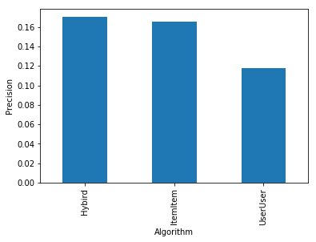

```python
byuser_results.groupby(['Algorithm']).precision.mean().plot.bar()
plt.ylabel('Precision')
```

### Bar plot of recall

As above

```
Text(0,0.5,'Recall')
```

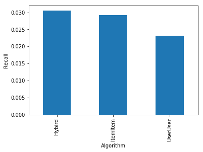

```python
byuser_results.groupby(['Algorithm']).recall.mean().plot.bar()
plt.ylabel('Recall')
```

### (Optional) Scatter plot of recall / precision

See example

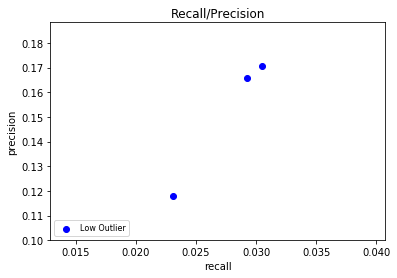

```python
x = list(byuser_results.groupby(['Algorithm']).recall.mean())
y = list(byuser_results.groupby(['Algorithm']).precision.mean())

plt.scatter(x,y,color = 'b')
plt.xlabel('recall')
plt.ylabel('precision')
plt.title('Recall/Precision')
plt.legend(
           ('Low Outlier', 'LoLo', 'Lo'),
           scatterpoints=1,
           loc='lower left',
           ncol=3,
           fontsize=8)
plt.show()
```

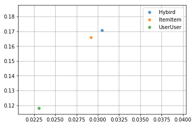

```python
fig, ax = plt.subplots()
for i in range(len(objects)):

    ax.scatter(x[i], y[i], label= objects[i],
               alpha=0.8, edgecolors='none')

ax.legend()
ax.grid(True)

plt.show()
```

## INFO 5871 only

In this section, you will attempt to use linear regression to learn optimal weights for the hybrid. The process is as follows:

- Extract one of the five partitions from the cross-validation iterator. This will be used to learn the weights and then not used for evaluation.
- Train the user-based and item-based algorithms on this partition.
- Use `batch.predict` to compute predictions over the test data.
- Construct a linear regression (`sklearn.linear_model` with `fit_intercept` equal to `False`) with the real test set ratings as the predicted variable and the predictions of the two algorithms as the independent variables.
- Use the coefficients learned by this process to construct a new hybrid.
- Use the remaining four folds of the data to do an evaluation, collecting both prediction values and recommendation lists.
- Following the same methodology as above, produce plots (with error bars) of RMSE and nDCG.
- Don't forget to answer the question at the end.

```python
from sklearn.linear_model import LinearRegression
```

### Get one partition for training weights

### Train and predict components on first partition

### Create numpy arrays of predictions and actual ratings

### Run linear regression

fit_intercept = False

### Print regression coefficients

### Create hybrid with regression coefficients as weights

### Run experiment

Do both prediction and recommendation experiments

### Compute RMSE results

Average over the four folds

### Compute nDCG

Average the users over each fold, then average the folds

### Question:

The optimization procedue produces a hybrid that has a lower RMSE than either component. But that hybrid does not have the highest nDCG. Why did this happen? What must be true about the distribution of errors such that this hybrid does not produce the best ranking?